# Crisp vs. Fuzzy $k$-means

## Part 1: Computational Performance

It is to be expected that the fuzzy method requires more CPU time since we have a full dependency between every data point and every cluster prototype. For example, we need to calculate the membership values for every (point, prototype) combination. The attached paper has some benchmarks which show that this is indeed the case.

## Part 3: Image Segmentation

```python
import numpy as np
from sklearn.datasets import load_sample_image
from sklearn.neighbors import NearestNeighbors
from skimage.transform import rescale
from skimage.util import random_noise
import matplotlib.pyplot as plt
from mpl_toolkits.mplot3d import Axes3D
import skfuzzy
import sys
sys.path.append('../../fonts')
from set_font import set_font
```

### Load the Image

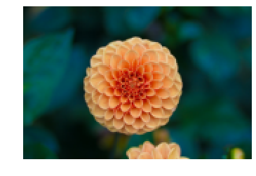

```python
image = rescale(load_sample_image('flower.jpg') / 255, 0.25)
plt.imshow(image)
plt.axis('off');
```

### Generate Noisy Images

```python
noise_ratios = [0.0, 0.02, 0.05]
images_noise = [random_noise(image, mode='s&p', amount=noise_ratio, seed=1) for noise_ratio in noise_ratios]
```

### Image Segmentation

```python
def cluster_image(image, n_clusters, fuzzifier):
    # Cluster the image pixels (colours)
    data = image.reshape(-1, 3)
    centroids = skfuzzy.cmeans(data.transpose(), c=n_clusters, m=fuzzifier, error=0.0001, maxiter=2000, seed=1)[0]

    # Find the closest cluster for each pixel
    nbrs = NearestNeighbors(n_neighbors=1).fit(centroids)
    cluster_labels = nbrs.kneighbors(data)[1]

    # Replace each pixel with the corresponding centroid colour
    image_seg = centroids[cluster_labels]
    image_seg = image_seg.reshape(image.shape)

    return image_seg
```

### Visualize the Result

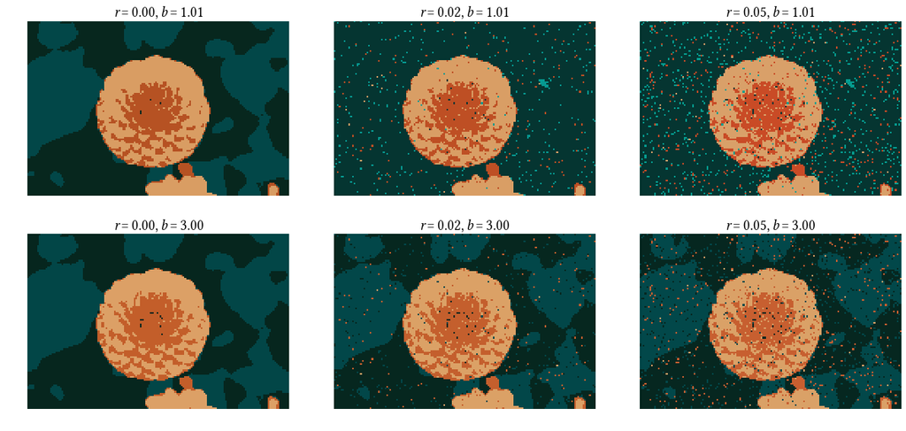

```python
set_font()
fig, axes = plt.subplots(2, 3, figsize=(17, 8))
n_clusters = 4

for ax, image_noise, noise in zip(axes[0, :], images_noise, noise_ratios):
    fuzzifier = 1.01
    image_clustered = cluster_image(image_noise, n_clusters, fuzzifier)
    ax.imshow(image_clustered)
    ax.set_title('$r = %.2f, b = %.2f$' % (noise, fuzzifier))
    ax.axis('off')

for ax, image_noise, noise in zip(axes[1, :], images_noise, noise_ratios):
    fuzzifier = 3
    image_clustered = cluster_image(image_noise, n_clusters, fuzzifier)
    ax.imshow(image_clustered)
    ax.set_title('$r = %.2f, b = %.2f$' % (noise, fuzzifier))
    ax.axis('off')

fig.tight_layout()
#fig.savefig('../assignment06/figures/CrispVsFuzzy.pdf', bbox_inches='tight')
```

### Interpretation

- With the crisp clustering method, the results change quite a lot. The background structure is not always detected well and the colour inside the flowers varies (much more saturated brown). The results also depend heavily on the used seed.
- The fuzzy method, on the other hand, is relatively stable. The detected structure and the colours stays roughly the same. Also, the results vary less with when using different seeds.

It is to note that the noise pixels are outliers in the colour space (since salt & pepper produces extreme values):

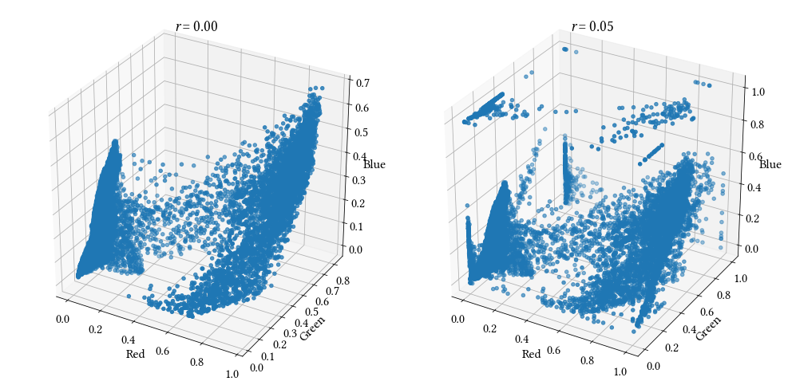

```python
fig = plt.figure(figsize=(14, 7))

ax = fig.add_subplot(1, 2, 1, projection='3d')
image_data = images_noise[0].reshape(-1, 3)
ax.scatter(image_data[:, 0], image_data[:, 1], image_data[:, 2])
ax.set_xlabel('Red')
ax.set_ylabel('Green')
ax.set_zlabel('Blue')
ax.set_title('$r = %.2f$' % noise_ratios[0])

ax = fig.add_subplot(1, 2, 2, projection='3d')
image_data = images_noise[-1].reshape(-1, 3)
ax.scatter(image_data[:, 0], image_data[:, 1], image_data[:, 2])
ax.set_xlabel('Red')
ax.set_ylabel('Green')
ax.set_zlabel('Blue')
ax.set_title('$r = %.2f$' % noise_ratios[-1])

fig.tight_layout()
```

Especially the crisp method is influenced by these outliers. However, even though the fuzzy method gets less distorted by these outliers, this has only an effect on the resulting *colour* values. It does not mean that the image *pixels* are now noise free. This is not possible with fuzzy $k$-means and also not intended. The noise colours still get assigned to one of the clusters resulting in a noise image.

```python
sol_vars = ['image', 'noise_ratios', 'images_noise']
sol_vars_code = [{
    'name': 'cluster_image',
    'description': 'Checks if the function cluster_image is implemented properly.',
    'code': 'cluster_image(image, 4, 3)'
}]
```